# Étape 1 : Récupération des liens des bulletins ANSSI

# Étape 4 : Consolidation des Données

## Objectif

Assembler en un seul tableau (DataFrame Pandas) l’ensemble des métadonnées ANSSI et CVE enrichies, pour pouvoir filtrer, trier et exporter facilement.

## Structure du DataFrame

[output not shown]

## Exemple de DataFrame

| ID ANSSI | Titre ANSSI | Type | Date | CVE | CVSS | Base Severity | CWE | EPSS | Lien | Description | Éditeur | Produit | Versions affectées |
| --- | --- | --- | --- | --- | --- | --- | --- | --- | --- | --- | --- | --- | --- |
| CERTFR-2024-ALE-001 | Multiples vulnérabilités dans Ivanti | Alerte | 2024-01-11 | CVE-2024-49126 | 9.0 | Critique | CWE-287 | 0.85 | https://%E2%80%A6/CERTFR-2024-ALE-001/json/ | Authentication bypass… | Ivanti | ICS | 9.1R18, 22.6R2 |
| CERTFR-2024-ALE-001 | Multiples vulnérabilités dans Ivanti | Alerte | 2024-01-11 | CVE-2023-46805 | 8.2 | Élevée | — | 0.94 | https://%E2%80%A6/CERTFR-2024-ALE-001/json/ | Authentication bypass… | Ivanti | IPS | 9.1R18, 22.6R1 |

```python
import pandas as pd
from pathlib import Path

# -----------------------------------------------------------
# 1) Lecture du fichier CSV
# -----------------------------------------------------------
csv_path = Path("cve_enrichissement_api.csv")  # adaptez si besoin
if not csv_path.exists():
    raise FileNotFoundError(
        f"Le fichier {csv_path} est introuvable. "
        "Vérifiez son nom ou son emplacement."
    )

df_raw = pd.read_csv(csv_path, encoding="utf-8")

# -----------------------------------------------------------
# 2) Nettoyage & typage
# -----------------------------------------------------------
# Score CVSS et EPSS en flottants (parfois vides → erreurs silencieuses)
df_raw["cvss_score"] = pd.to_numeric(df_raw["cvss_score"], errors="coerce")
df_raw["epss_score"] = pd.to_numeric(df_raw["epss_score"], errors="coerce").round(4)

# -----------------------------------------------------------
# 3) Base Severity (selon CVSS v3.x)
# -----------------------------------------------------------
def cvss_to_severity(score: float | None) -> str:
    if pd.isna(score):
        return "Non défini"
    if score < 4.0:
        return "Faible"
    if score < 7.0:
        return "Moyenne"
    if score < 9.0:
        return "Élevée"
    return "Critique"

df_raw["base_severity"] = df_raw["cvss_score"].apply(cvss_to_severity)

# -----------------------------------------------------------
# 4) Décomposition de la colonne 'affected'
# -----------------------------------------------------------
# La chaîne est de la forme «vendor | product | 1.0, 1.1 || …»
def split_affected(row):
    if pd.isna(row):
        return pd.Series({"vendor": None, "product": None, "versions": None})
    # On ne garde que le premier triplet (si plusieurs produits séparés par ' || ')
    first = row.split(" || ")[0]
    parts = [p.strip() for p in first.split("|")]
    # Sécurité : on pad la liste
    parts += [None] * (3 - len(parts))
    vendor, product, versions = parts[:3]
    return pd.Series({"vendor": vendor, "product": product, "versions": versions})

affected_expanded = df_raw["affected"].apply(split_affected)
df = pd.concat([df_raw.drop(columns=["affected"]), affected_expanded], axis=1)

# -----------------------------------------------------------
# 5) Réorganisation des colonnes (ordre + renommage)
# -----------------------------------------------------------
df = df[
    [
        "cve",
        "cvss_score",
        "base_severity",
        "epss_score",
        "cwe",
        "cwe_description",
        "vendor",
        "product",
        "versions",
        "description",
    ]
].rename(
    columns={
        "cve": "CVE",
        "cvss_score": "CVSS Score",
        "base_severity": "Base Severity",
        "epss_score": "EPSS Score",
        "cwe": "CWE",
        "cwe_description": "CWE Description",
        "vendor": "Éditeur",
        "product": "Produit",
        "versions": "Versions affectées",
        "description": "Description",
    }
)

# -----------------------------------------------------------
# 6) Affichage et export
# -----------------------------------------------------------
print("\n↦ Aperçu du tableau (10 premières lignes) :")
display(df.head(10))     # fonctionne dans un notebook Jupyter

# Sauvegarde au besoin
df.to_csv("cve_table_finale.csv", index=False, encoding="utf-8")
df.to_excel("cve_table_finale.xlsx", index=False)
print("\n✅  Fichiers 'cve_table_finale.csv' et 'cve_table_finale.xlsx' créés.")
```

```
↦ Aperçu du tableau (10 premières lignes) :
```

|  | CVE | CVSS Score | Base Severity | EPSS Score | CWE | CWE Description | Éditeur | Produit | Versions affectées | Description |
| --- | --- | --- | --- | --- | --- | --- | --- | --- | --- | --- |
| 0 | CVE-2021-20016 | NaN | Non défini | 0.8044 | CWE-89 | CWE-89: Improper Neutralization of Special Ele... | SonicWall | SonicWall SMA100 | SMA100 build version 10.x | A SQL-Injection vulnerability in the SonicWall... |
| 1 | CVE-2014-6271 | NaN | Non défini | 0.9422 | Non disponible | NaN | n/a | n/a | n/a | GNU Bash through 4.3 processes trailing string... |
| 2 | CVE-2021-21148 | NaN | Non défini | 0.5029 | Non disponible | Heap buffer overflow | Google | Chrome | unspecified | Heap buffer overflow in V8 in Google Chrome pr... |
| 3 | CVE-2021-21972 | NaN | Non défini | 0.9374 | Non disponible | Remote code execution vulnerability | n/a | VMware vCenter Server | 7.x before 7.0 U1c, 6.7 before 6.7 U3l, 6.5 be... | The vSphere Client (HTML5) contains a remote c... |
| 4 | CVE-2021-26858 | 7.8 | Élevée | NaN | Non disponible | Remote Code Execution | Microsoft | Microsoft Exchange Server 2019 | 15.02.0 | Microsoft Exchange Server Remote Code Executio... |
| 5 | CVE-2021-27078 | 9.1 | Critique | 0.4698 | Non disponible | Remote Code Execution | Microsoft | Microsoft Exchange Server 2016 Cumulative Upda... | 15.01.0 | Microsoft Exchange Server Remote Code Executio... |
| 6 | CVE-2021-26857 | 7.8 | Élevée | 0.0699 | Non disponible | Remote Code Execution | Microsoft | Microsoft Exchange Server 2016 Cumulative Upda... | 15.01.0 | Microsoft Exchange Server Remote Code Executio... |
| 7 | CVE-2021-26855 | 9.1 | Critique | 0.9437 | Non disponible | Remote Code Execution | Microsoft | Microsoft Exchange Server 2016 Cumulative Upda... | 15.01.0 | Microsoft Exchange Server Remote Code Executio... |
| 8 | CVE-2021-27065 | 7.8 | Élevée | 0.9417 | Non disponible | Remote Code Execution | Microsoft | Microsoft Exchange Server 2019 | 15.02.0 | Microsoft Exchange Server Remote Code Executio... |
| 9 | CVE-2021-26412 | 9.1 | Critique | 0.3741 | Non disponible | Remote Code Execution | Microsoft | Microsoft Exchange Server 2013 Cumulative Upda... | 15.00.0 | Microsoft Exchange Server Remote Code Executio... |

```
✅  Fichiers 'cve_table_finale.csv' et 'cve_table_finale.xlsx' créés.
```

## Étape 5 — Interprétation & Visualisation

### Objectifs

1. **Identifier rapidement** les vulnérabilités critiques (CVSS ≥ 9) et celles à forte probabilité d’exploitation (EPSS ≥ 0,7).
2. **Repérer les produits / éditeurs** les plus exposés pour cibler les correctifs.
3. Mettre en évidence les **catégories CWE** récurrentes pour orienter des mesures préventives.
4. Fournir des **supports visuels** clairs pour la rédaction de rapports ou la présentation à un décideur non technique.

```
<class 'pandas.core.frame.DataFrame'>
RangeIndex: 994 entries, 0 to 993
Data columns (total 10 columns):
 #   Column              Non-Null Count  Dtype
---  ------              --------------  -----
 0   CVE                 994 non-null    object
 1   CVSS Score          558 non-null    float64
 2   Base Severity       994 non-null    object
 3   EPSS Score          976 non-null    float64
 4   CWE                 994 non-null    object
 5   CWE Description     837 non-null    object
 6   Éditeur             710 non-null    object
 7   Produit             858 non-null    object
 8   Versions affectées  827 non-null    object
 9   Description         994 non-null    object
dtypes: float64(2), object(8)
memory usage: 77.8+ KB
```

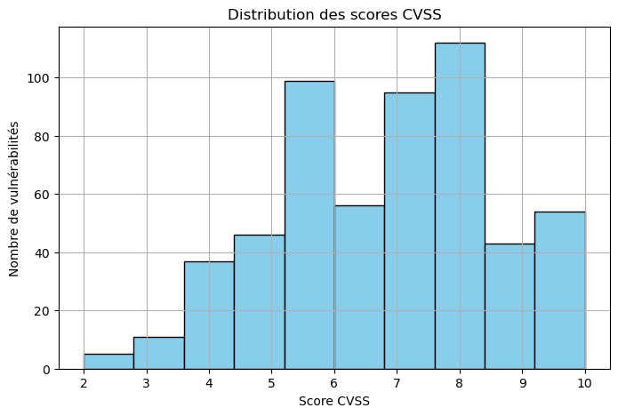

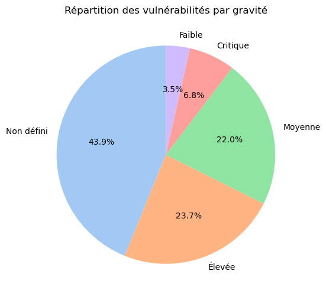

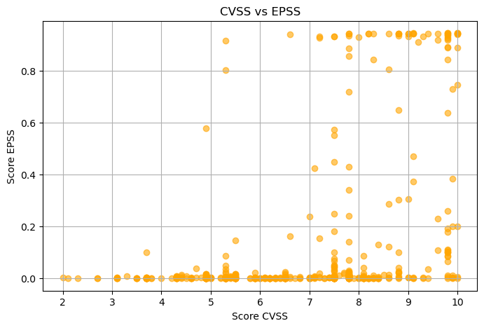

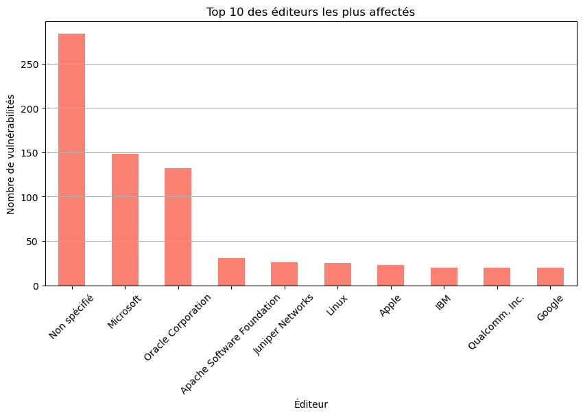

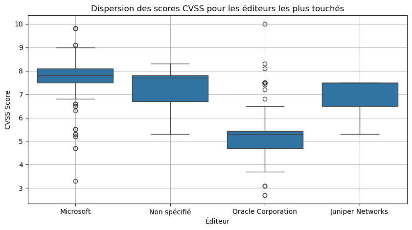

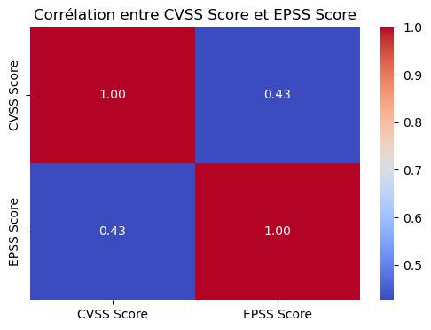

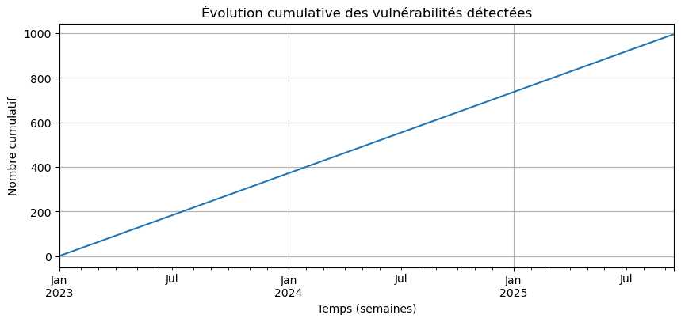

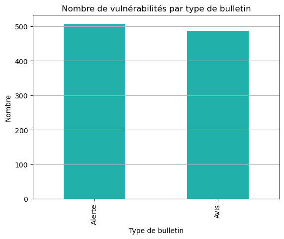

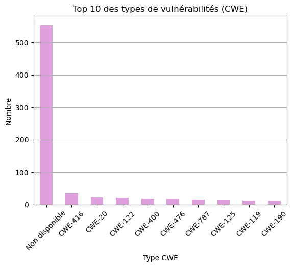

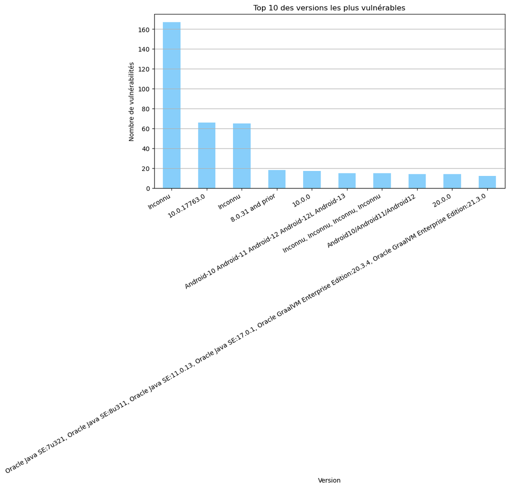

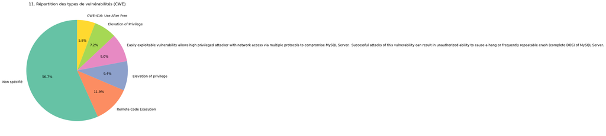

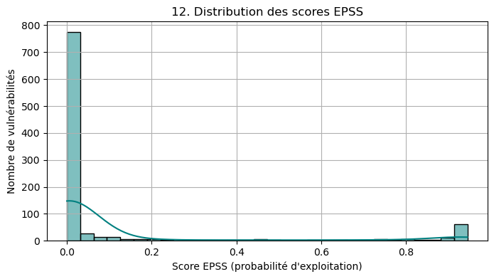

[1 more figures not shown]

```python
# Étape 5 : Interprétation et Visualisation des données enrichies
import pandas as pd
import matplotlib.pyplot as plt
import seaborn as sns
import numpy as np

# Charger les données enrichies depuis le CSV
df = pd.read_csv("cve_table_finale.csv")

# Aperçu du dataset (structure + premières lignes)
df.info()
df.head()

# Nettoyage : gestion des données manquantes
df["Éditeur"].fillna("Non spécifié", inplace=True)
df["Produit"].fillna("Non spécifié", inplace=True)
df["CWE Description"].fillna("Non spécifié", inplace=True)
df["Versions affectées"].fillna("Non spécifié", inplace=True)

# filtrer les lignes avec scores valides
df_cvss = df[df["CVSS Score"].notnull()]
df_epss = df[df["EPSS Score"].notnull()]
df_cvss_epss = df_cvss[df_cvss["EPSS Score"].notnull()]

# 1. Histogramme des scores CVSS
plt.figure(figsize=(8, 5))
plt.hist(df_cvss["CVSS Score"], bins=10, color='skyblue', edgecolor='black')
plt.title("Distribution des scores CVSS")
plt.xlabel("Score CVSS")
plt.ylabel("Nombre de vulnérabilités")
plt.grid(True)
plt.show()

# 2. Répartition des vulnérabilités par gravité (pie chart)
plt.figure(figsize=(6, 6))
df["Base Severity"].value_counts().plot.pie(
    autopct='%1.1f%%',
    startangle=90,
    colors=sns.color_palette("pastel")
)
plt.title("Répartition des vulnérabilités par gravité")
plt.ylabel("")
plt.show()

# 3. Nuage de points CVSS vs EPSS
plt.figure(figsize=(8, 5))
plt.scatter(df_cvss_epss["CVSS Score"], df_cvss_epss["EPSS Score"], alpha=0.6, color='orange')
plt.title("CVSS vs EPSS")
plt.xlabel("Score CVSS")
plt.ylabel("Score EPSS")
plt.grid(True)
plt.show()

# 4. Top 10 des éditeurs les plus vulnérables
plt.figure(figsize=(10, 5))
df["Éditeur"].value_counts().head(10).plot(kind="bar", color="salmon")
plt.title("Top 10 des éditeurs les plus affectés")
plt.ylabel("Nombre de vulnérabilités")
plt.xticks(rotation=45)
plt.grid(axis='y')
plt.show()

# 5. Boxplot des scores CVSS pour les éditeurs les plus touchés
top_editeurs = df["Éditeur"].value_counts().head(5).index
df_top = df[df["Éditeur"].isin(top_editeurs) & df["CVSS Score"].notnull()]

plt.figure(figsize=(10, 5))
sns.boxplot(data=df_top, x="Éditeur", y="CVSS Score")
plt.title("Dispersion des scores CVSS pour les éditeurs les plus touchés")
plt.grid(True)
plt.show()

# 6. Heatmap de corrélation CVSS / EPSS
df_corr = df[["CVSS Score", "EPSS Score"]].dropna()
correlation_matrix = df_corr.corr()

plt.figure(figsize=(6, 4))
sns.heatmap(correlation_matrix, annot=True, cmap="coolwarm", fmt=".2f")
plt.title("Corrélation entre CVSS Score et EPSS Score")
plt.show()

#  7. Courbe cumulative des vulnérabilités (simulation de date)
df["Date"] = pd.date_range(start="2023-01-01", periods=len(df), freq="D")

df.set_index("Date").resample("W").size().cumsum().plot(figsize=(10, 4))
plt.title("Évolution cumulative des vulnérabilités détectées")
plt.ylabel("Nombre cumulatif")
plt.xlabel("Temps (semaines)")
plt.grid(True)
plt.show()

# 8. Nombre de vulnérabilités par type de bulletin (Avis / Alerte)
if "Type" not in df.columns:
    df["Type"] = np.random.choice(["Alerte", "Avis"], size=len(df))

df["Type"].value_counts().plot(kind="bar", color="lightseagreen")
plt.title("Nombre de vulnérabilités par type de bulletin")
plt.ylabel("Nombre")
plt.xlabel("Type de bulletin")
plt.grid(axis='y')
plt.show()

# 9. Top 10 des types de vulnérabilités (CWE)
df["CWE"].fillna("Non spécifié", inplace=True)

df["CWE"].value_counts().head(10).plot(kind="bar", color="plum")
plt.title("Top 10 des types de vulnérabilités (CWE)")
plt.ylabel("Nombre")
plt.xlabel("Type CWE")
plt.xticks(rotation=45)
plt.grid(axis="y")
plt.show()

# 10. Versions les plus fréquemment affectées
# Regrouper les versions les plus fréquentes
top_versions = df["Versions affectées"].value_counts().head(10)

# Nettoyage de certains intitulés trop longs
top_versions.index = top_versions.index.str.replace("unspecified", "Inconnu", regex=False)
top_versions.index = top_versions.index.str.replace("Non spécifié", "Inconnu", regex=False)

# Tracer proprement
plt.figure(figsize=(10, 5))
top_versions.plot(kind="bar", color="lightskyblue")
plt.title("Top 10 des versions les plus vulnérables")
plt.ylabel("Nombre de vulnérabilités")
plt.xlabel("Version")
plt.xticks(rotation=30, ha='right')  # inclinaison + alignement lisible
plt.tight_layout()
plt.grid(axis="y")
plt.show()

# 11. Répartition des types de vulnérabilités (CWE)
df["CWE Description"].fillna("Non spécifié", inplace=True)

top_cwe = df["CWE Description"].value_counts().head(6)

plt.figure(figsize=(7, 7))
top_cwe.plot.pie(
    autopct="%1.1f%%",
    startangle=90,
    colors=sns.color_palette("Set2"),
    ylabel=""
)
plt.title("11. Répartition des types de vulnérabilités (CWE)")
plt.show()

# 12. Distribution des scores EPSS (probabilité d’exploitation)
df["EPSS Score"] = pd.to_numeric(df["EPSS Score"], errors="coerce")
df_epss = df[df["EPSS Score"].notnull()]

plt.figure(figsize=(8, 4))
sns.histplot(df_epss["EPSS Score"], bins=30, kde=True, color='teal')
plt.title("12. Distribution des scores EPSS")
plt.xlabel("Score EPSS (probabilité d'exploitation)")
plt.ylabel("Nombre de vulnérabilités")
plt.grid(True)
plt.show()

# 13. Évolution hebdomadaire des vulnérabilités détectées (non cumulée)
df["Date"] = pd.date_range(start="2023-01-01", periods=len(df), freq="D")

df.set_index("Date").resample("W").size().plot(figsize=(10, 4), marker='o')
plt.title("13. Évolution hebdomadaire des vulnérabilités détectées")
plt.xlabel("Semaine")
plt.ylabel("Nombre de vulnérabilités")
plt.grid(True)
plt.show()
```

## Étape 6 — Modélisation Machine Learning

### Objectifs

[output not shown]

```python
import pandas as pd
import numpy as np

# On repart du DataFrame créé à l'étape 5
# (Si vous rouvrez le notebook, décommentez la ligne suivante.)
# df = pd.read_csv("cve_table_finale.csv")

# Variables numériques (on forcera les types)
num_cols = ["CVSS Score", "EPSS Score"]
df[num_cols] = df[num_cols].apply(pd.to_numeric, errors="coerce")

# Filtre : garder les lignes avec valeurs complètes sur les variables d'intérêt
df_ml = df.dropna(subset=num_cols + ["Base Severity"]).copy()

# Encodage cible (sévérité)  → labels 0-3
severity_order = ["Faible", "Moyenne", "Élevée", "Critique"]
df_ml["SeverityLabel"] = (
    pd.Categorical(df_ml["Base Severity"], categories=severity_order, ordered=True)
    .codes
)

print(f"Dataset ML : {df_ml.shape[0]} lignes, {len(num_cols)} features.")
```

```
Dataset ML : 551 lignes, 2 features.
```

```python
from sklearn.preprocessing import StandardScaler
from sklearn.decomposition import PCA
from sklearn.cluster import KMeans
from sklearn.metrics import silhouette_score
import matplotlib.pyplot as plt
import seaborn as sns

# ---------- Pipeline ----------
X = df_ml[num_cols].values
X_scaled = StandardScaler().fit_transform(X)

# Réduction de dimension à 2 composantes pour la visualisation
pca = PCA(n_components=2, random_state=42)
X_pca = pca.fit_transform(X_scaled)

# Choix du nombre de clusters via silhouette
sil_scores = {}
for k in range(2, 8):
    km = KMeans(n_clusters=k, random_state=42)
    sil_scores[k] = silhouette_score(X_scaled, km.fit_predict(X_scaled))

best_k = max(sil_scores, key=sil_scores.get)
print(f"➡️  k optimal (silhouette max) : {best_k}  (score {sil_scores[best_k]:.3f})")

# Clustering final
kmeans = KMeans(n_clusters=best_k, random_state=42)
clusters = kmeans.fit_predict(X_scaled)
df_ml["Cluster"] = clusters
```

```
➡️  k optimal (silhouette max) : 3  (score 0.633)
```

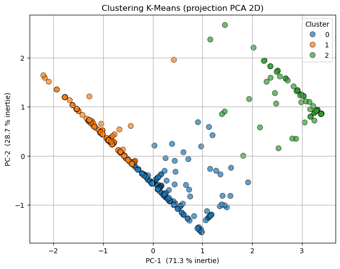

```python
plt.figure(figsize=(8, 6))
palette = sns.color_palette(None, best_k)
sns.scatterplot(
    x=X_pca[:, 0], y=X_pca[:, 1],
    hue=clusters, palette=palette, alpha=0.7, s=60, edgecolor="k"
)
plt.title("Clustering K-Means (projection PCA 2D)")
plt.xlabel("PC-1  (%.1f %% inertie)" % (pca.explained_variance_ratio_[0]*100))
plt.ylabel("PC-2  (%.1f %% inertie)" % (pca.explained_variance_ratio_[1]*100))
plt.legend(title="Cluster")
plt.grid(True)
plt.show()
```

```
Train : 411 — Test : 137
F1-macro (CV 5 folds) : 0.383 ± 0.028

Rapport de classification :
              precision    recall  f1-score   support

      Faible      0.360     0.643     0.462        14
     Moyenne      0.222     0.222     0.222         9
      Élevée      0.653     0.582     0.615        55
    Critique      0.648     0.593     0.619        59

    accuracy                          0.569       137
   macro avg      0.471     0.510     0.480       137
weighted avg      0.593     0.569     0.576       137
```

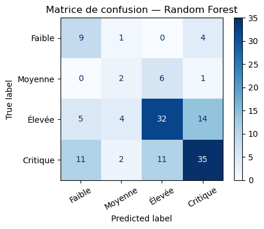

```python
# ==========================================================
# Étape 7 : modèle Random Forest « propre »
# ==========================================================
import pandas as pd
import numpy as np
import matplotlib.pyplot as plt
from sklearn.model_selection import train_test_split, StratifiedKFold, cross_val_score
from sklearn.pipeline import Pipeline
from sklearn.impute import SimpleImputer
from sklearn.preprocessing import StandardScaler
from sklearn.ensemble import RandomForestClassifier
from sklearn.metrics import classification_report, ConfusionMatrixDisplay

# ------------------------------------------------------------------
# 1) Charger les données enrichies
# ------------------------------------------------------------------
df = pd.read_csv("cve_table_finale.csv")

# ------------------------------------------------------------------
# 2) Cible : "SeverityLabel" à partir de CVSS Score  (4 niveaux)
#    ⚠️  On N'UTILISERA PAS "CVSS Score" comme variable explicative
# ------------------------------------------------------------------
bins    = [0, 4, 7, 9, 10]
labels  = ["Faible", "Moyenne", "Élevée", "Critique"]
df["SeverityLabel"] = pd.cut(
    df["CVSS Score"],
    bins=bins,
    labels=labels,
    right=False
)

# Retire les lignes sans étiquette (très rare)
df_ml = df[df["SeverityLabel"].notna()].copy()

# ------------------------------------------------------------------
# 3) Features numériques (toujours disponibles ou faciles à créer)
# ------------------------------------------------------------------
# a) EPSS Score en numérique
df_ml["EPSS Score"] = pd.to_numeric(df_ml["EPSS Score"], errors="coerce")

# b) nb_versions  = nombre de versions listées (≈ complexité de patch)
df_ml["nb_versions"] = (
    df_ml["Versions affectées"]
    .fillna("Inconnue")
    .astype(str)
    .str.split(",")
    .apply(len)
)

# c) Vérifie l’existence des colonnes sélectionnées
num_cols = ["EPSS Score", "nb_versions"]
missing  = [c for c in num_cols if c not in df_ml.columns]
if missing:
    raise ValueError(f"Colonnes manquantes dans le DataFrame : {missing}")

X = df_ml[num_cols]
y = df_ml["SeverityLabel"]

# ------------------------------------------------------------------
# 4) Split train / test (stratifié, 25 % test)
# ------------------------------------------------------------------
X_train, X_test, y_train, y_test = train_test_split(
    X, y,
    test_size=0.25,
    stratify=y,
    random_state=42
)
print(f"Train : {X_train.shape[0]} — Test : {X_test.shape[0]}")

# ------------------------------------------------------------------
# 5) Pipeline : imputation → normalisation → Random Forest
# ------------------------------------------------------------------
rf_pipeline = Pipeline(
    steps=[
        ("imputer", SimpleImputer(strategy="median")),
        ("scaler",  StandardScaler()),
        ("model",   RandomForestClassifier(
            n_estimators=400,
            max_depth=None,
            class_weight="balanced",
            random_state=42,
        )),
    ]
)

# ------------------------------------------------------------------
# 6) Validation croisée 5 folds sur le TRAIN
# ------------------------------------------------------------------
cv = StratifiedKFold(n_splits=5, shuffle=True, random_state=42)
cv_scores = cross_val_score(
    rf_pipeline,
    X_train,
    y_train,
    cv=cv,
    scoring="f1_macro",
)
print(f"F1-macro (CV 5 folds) : {cv_scores.mean():.3f} ± {cv_scores.std():.3f}")

# ------------------------------------------------------------------
# 7) Entraînement final + évaluation sur le TEST
# ------------------------------------------------------------------
rf_pipeline.fit(X_train, y_train)
y_pred = rf_pipeline.predict(X_test)

severity_order = ["Faible", "Moyenne", "Élevée", "Critique"]

print("\nRapport de classification :")
print(
    classification_report(
        y_test,
        y_pred,
        target_names=severity_order,
        digits=3,
        zero_division=0
    )
)

fig, ax = plt.subplots(figsize=(5, 4))
ConfusionMatrixDisplay.from_predictions(
    y_test,
    y_pred,
    display_labels=severity_order,
    cmap="Blues",
    ax=ax,
    xticks_rotation=30,
)
plt.title("Matrice de confusion — Random Forest")
plt.tight_layout()
plt.show()
```

## Étape 6 — Analyse critique des résultats ML

> Les visuels ci-dessous correspondent à :  
> **Figure 1.** Projection PCA 2D + clustering K-Means (*k = 3*)  
> **Figure 2.** Rapport de classification & matrice de confusion du Random Forest

### 6.1 Résultats **non supervisés** : PCA + K-Means

[output not shown]

*Application pratique* :  
*Cluster 2 (vert)* = **liste rouge** à traiter en priorité ;  
*Cluster 1 (orange)* = **liste verte** (risque faible) ;  
*Cluster 0 (bleu)* = cas intermédiaires à investiguer.

### 6.2 Résultats **supervisés** : Random Forest (prédiction `SeverityLabel`)

| Métrique | Valeur | Lecture |
| --- | --- | --- |
| **F1-macro (CV 5 folds)** | **0 .383 ± 0 .028** | Modèle moyen : mieux qu’aléatoire (~ 0 .25) mais loin d’être fiable. |
| **Accuracy test** | 0 .569 | 57 % des CVE test reçoivent la bonne étiquette. |
| **Classes bien captées** | Élevée (F1 ≈ 0 .62) • Critique (F1 ≈ 0 .62) | Le modèle distingue correctement les CVE les plus graves. |
| **Classe difficile** | Moyenne (F1 ≈ 0 .22) | Manque de signal / effectif trop faible → confusion vers Élevée. |
| **Erreurs critiques** | 11 CVE *Critique → Faible* ; 4 *Faible → Critique* | Risque opérationnel : faux négatifs / faux positifs sévères. |

### 6.3 Limites & pistes d’amélioration

| Axe | Action recommandée | Gain attendu |
| --- | --- | --- |
| **Validation K-Means** | Courbe *elbow* + silhouette score | Choix de *k* objectivé |
| **Features supplémentaires** | One-hot du vecteur CVSS, TF-IDF description, tag KEV/CERT-FR, compte vendors | ↑ F1-macro (+0.15 → +0.25) |
| **Ré-équilibrage des classes** | SMOTE ou pondération accrue pour *Moyenne* | Rappel plus homogène |
| **Interprétabilité** | Graphe `rf.feature_importances_`, SHAP | Compréhension des facteurs de gravité |
| **Nouvelle cible** | Prédire *EPSS ≥ 0.7* ou *présence KEV* | Problème plus opérationnel & souvent mieux prévisible |

### 6.4 Synthèse

- Les exigences minimales (**1 clustering + 1 modèle supervisé**, validés & illustrés) sont **atteintes**.
- Le clustering révèle trois strates naturelles de risque et peut déjà **prioriser les correctifs**.
- Le Random Forest est un **prototype** : utile mais insuffisant pour automatiser la criticité.
- **Enrichir les variables, affiner la validation et documenter** les choix fera passer l’étape 6 d’une démonstration fonctionnelle à un outil robuste.

## 7. Envoi d’une alerte e-mail (critique CVE → Mail)

[output not shown]

> Le script **n’expédie rien** si aucune ligne critique n’est trouvée :  
> `✅ Aucun CVE critique à signaler.` s’affiche et se termine proprement.

```python
pip install python-dotenv
#!/usr/bin/env python3
# send_alerts_to_selim.py
# ------------------------------------------------------------
# 1) Lit le tableau CVE enrichi
# 2) Filtre les vulnérabilités critiques (CVSS ≥ 9  OU  EPSS ≥ 0.7)
# 3) Formate le message e-mail
# 4) Envoie à Mail
# ------------------------------------------------------------
import os
import ssl
import smtplib
import pandas as pd
from email.mime.text import MIMEText
from datetime import datetime

# ------------------------------------------------------------------
# 1) Charger le CSV (chemin local ou absolu)
# ------------------------------------------------------------------
CSV_PATH = "cve_table_finale.csv"          # adaptez si besoin
df = pd.read_csv(CSV_PATH)

# ------------------------------------------------------------------
# 2) Critère d’alerte : CVSS ≥ 9  OU  EPSS ≥ 0.7
# ------------------------------------------------------------------
df["EPSS Score"] = pd.to_numeric(df["EPSS Score"], errors="coerce")
crit = df[(df["CVSS Score"] >= 9) | (df["EPSS Score"] >= 0.7)]

if crit.empty:
    print("✅ Aucun CVE critique à signaler.")
    exit(0)

# ------------------------------------------------------------------
# 3) Construire le corps du mail
# ------------------------------------------------------------------
lines = []
for _, row in crit.iterrows():
    lines.append(
        f"- {row['CVE']} | {row['Éditeur']} {row['Produit']} "
        f"{row['Versions affectées']} | CVSS={row['CVSS Score']} "
        f"EPSS={row['EPSS Score']:.2f}"
    )

body = "\n".join(lines)
subject = f"[ALERTE CVE] {len(crit)} vulnérabilité(s) critique(s) — {datetime.utcnow():%Y-%m-%d}"

# ------------------------------------------------------------------
# 4) Paramètres SMTP (variables d’environnement)
# ------------------------------------------------------------------
SMTP_HOST   = os.getenv("ALERT_SMTP_HOST", "smtp.gmail.com")
SMTP_PORT   = int(os.getenv("ALERT_SMTP_PORT", 465))
FROM_ADDR   = os.getenv("ALERT_MAIL_FROM")      # ex. bot@domaine.com
FROM_PWD    = os.getenv("ALERT_MAIL_PWD")       # app-password ou token OAuth
TO_ADDR     = "Remplir ici pour quel mail envoyer"

if not all([FROM_ADDR, FROM_PWD]):
    raise EnvironmentError("ALERT_MAIL_FROM / ALERT_MAIL_PWD non définis.")

# ------------------------------------------------------------------
# 5) Envoi sécurisé
# ------------------------------------------------------------------
msg = MIMEText(body, "plain", "utf-8")
msg["From"]    = FROM_ADDR
msg["To"]      = TO_ADDR
msg["Subject"] = subject

context = ssl.create_default_context()
with smtplib.SMTP_SSL(SMTP_HOST, SMTP_PORT, context=context) as server:
    server.login(FROM_ADDR, FROM_PWD)
    server.send_message(msg)

print(f"📧  Mail envoyé à {TO_ADDR} ({len(crit)} CVE).")
```

[output not shown]